# Deep Learning Notes

# Vocabularly

- neuron: is that the “nodes”/circles that make up the layers?
- layers
- Sequential
- Dense
- optmizer
- learning rate
  - why does that matter?
- bactch size

Layer activations:

- relu function
- sigmoid function
- softmax function
- softplus function
- softsign function
- tanh function
- selu function
- elu function
- exponential function

Core layers

- Input object
- Dense layer
- Activation layer
- Embedding layer
- Masking layer
- Lambda layer

Convolution layers - Conv1D layer - Conv2D layer - Conv3D layer - SeparableConv1D layer - SeparableConv2D layer - DepthwiseConv2D layer - Conv1DTranspose layer - Conv2DTranspose layer - Conv3DTranspose layer

Pooling layers - MaxPooling1D layer - MaxPooling2D layer - MaxPooling3D layer - AveragePooling1D layer - AveragePooling2D layer - AveragePooling3D layer - GlobalMaxPooling1D layer - GlobalMaxPooling2D layer - GlobalMaxPooling3D layer - GlobalAveragePooling1D layer - GlobalAveragePooling2D layer - GlobalAveragePooling3D layer

Recurrent layers - LSTM layer - GRU layer - SimpleRNN layer - TimeDistributed layer - Bidirectional layer - ConvLSTM1D layer - ConvLSTM2D layer - ConvLSTM3D layer - Base RNN layer

…many more…

Activation layers: - ReLU layer - Softmax layer - LeakyReLU layer - PReLU layer - ELU layer - ThresholdedReLU layer

Choose a dog name:

```python
import pandas as pd
import numpy as np

from keras.models import Sequential
from keras.layers import Dense
import tensorflow

from sklearn.model_selection import train_test_split
from sklearn.metrics import mean_squared_error, r2_score

import seaborn as sns

data = pd.read_excel("C:/Users/brigh/Downloads/ENB2012_data.xlsx")
# data = pd.read_excel('assets/ENB2012_data.xlsx')
```

```python
X = data.drop(axis=1, columns=['Y1', 'Y2'])
y = pd.concat([data['Y1'], data['Y2']], axis=1)

x_train, x_test, y_train, y_test = train_test_split(X, y, test_size = 0.2, random_state = 314)
```

```python
model = Sequential()
model.add(Dense(8, input_shape=(8,), activation='relu'))
model.add(Dense(6, activation='relu'))
model.add(Dense(6, activation='relu'))
# model.add(Dense(4, activation='relu'))
model.add(Dense(4, activation='relu'))
model.add(Dense(2, activation='relu'))
```

```python
y_pred = model.predict(x_test)

print(f'R-Squared: {r2_score(y_test, y_pred):.4}')
print(f'Mean Squared Error: {mean_squared_error(y_test, y_pred, squared = True):.4}')
```

```
R-Squared: -5.274
Mean Squared Error: 627.9
```

```python
from plot_keras_history import show_history, plot_history
import matplotlib.pyplot as plt
```

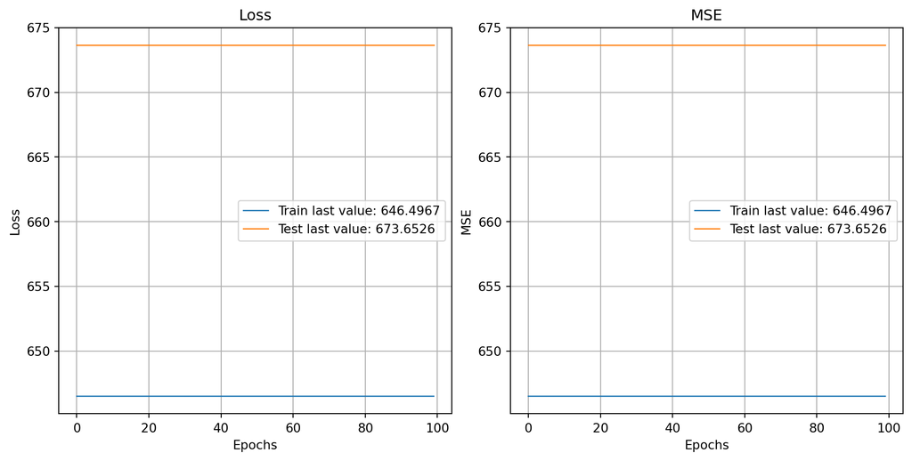

```python
show_history(history)
plot_history(history)
plt.close()
```

```python
model_history = pd.DataFrame({
  'epoch': pd.Series(history.epoch),
  'loss': pd.Series(history.history.values())[0]
  })
model_history.head()
```

|  | epoch | loss |
| --- | --- | --- |
| 0 | 0 | 646.496582 |
| 1 | 1 | 646.496704 |
| 2 | 2 | 646.496704 |
| 3 | 3 | 646.496704 |
| 4 | 4 | 646.496765 |

# Success Metrics for Regression

```
- Mean Squared Error (MSE)
- R-Squared
```

Others: - Sum of Squared Error (SSE) - Sum of of Squared Regression Error (SSR) - Total Sum of Squared (SSTO)

# Success Metrics for Classification

```
- Accuracy
- Precision
- Recall
- F1
- AUC/ROC
```

play with finances plan party invite party winco appnt return dresses